# yolo_start_02_v10_2409

### yolo8 모델 성능 개선

```python
!pip install ultralytics
```

```
Downloading ultralytics-8.3.17-py3-none-any.whl (876 kB)
   ━━━━━━━━━━━━━━━━━━━━━━━━━━━━━━━━━━━━━━━━ 876.6/876.6 kB 40.7 MB/s eta 0:00:00
Downloading ultralytics_thop-2.0.9-py3-none-any.whl (26 kB)
```

```python
from ultralytics import YOLO
import cv2                                      # OpenCV 라이브러리를 불러오기
from google.colab.patches import cv2_imshow     # from google.colab.patches import cv2_imshow: Google Colab 환경에서 OpenCV 이미지를 표시하기 위한 함수

# YOLOv8 모델 로드
model = YOLO('yolov8n.pt')  # YOLOv8의 경량 모델

# 이미지 로드
img = cv2.imread('Dog_rawPixel01.jpg')

# 객체 탐지
# 로드된 YOLOv8 모델을 사용하여 이미지에서 객체를 탐지합니다. results 변수에는 탐지 결과가 저장
results = model(img)

# 결과 시각화
# plot() 함수는 탐지된 객체 주변에 경계 상자를 그려 이미지를 반환
img_with_detections = results[0].plot()  # 첫 번째 결과를 시각화

# 결과 이미지 표시
cv2_imshow(img_with_detections)
```

```
Output hidden; open in https://colab.research.google.com to view.
```

### 다른 이미지 확인

```
0: 640x448 1 umbrella, 2 chairs, 1 couch, 1 bed, 1 dining table, 1 book, 39.6ms
Speed: 2.9ms preprocess, 39.6ms inference, 1.4ms postprocess per image at shape (1, 3, 640, 448)
```

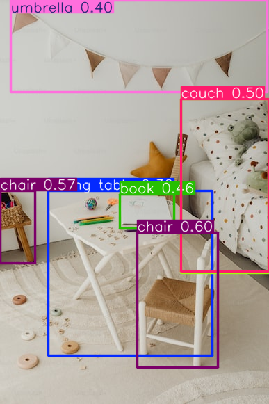

```python
# 이미지 로드
img = cv2.imread('life_unsplash.jpeg')

# 객체 탐지
# 로드된 YOLOv8 모델을 사용하여 이미지에서 객체를 탐지합니다. results 변수에는 탐지 결과가 저장
results = model(img)

# 결과 시각화
# plot() 함수는 탐지된 객체 주변에 경계 상자를 그려 이미지를 반환
img_with_detections = results[0].plot()  # 첫 번째 결과를 시각화

# 결과 이미지 표시
cv2_imshow(img_with_detections)
```

### 성능 개선 - 더 좋은 모델 사용

```python
# YOLO8의 주요 모델 크기는 다음과 같습니다 (작은 것부터 큰 순서로):

# YOLOv8n (nano)
# YOLOv8s (small)
# YOLOv8m (medium)
# YOLOv8l (large)
# YOLOv8x (extra large)
```

```
0: 640x448 1 chair, 1 bed, 1 dining table, 1 book, 1 scissors, 48.9ms
Speed: 2.2ms preprocess, 48.9ms inference, 1.9ms postprocess per image at shape (1, 3, 640, 448)
```

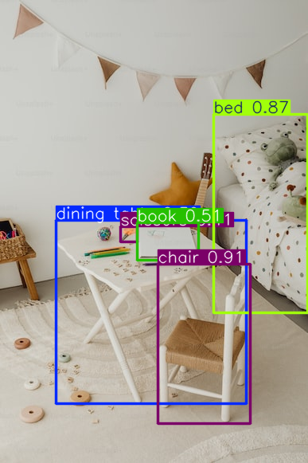

```python
from ultralytics import YOLO
import cv2                                      # OpenCV 라이브러리를 불러오기
from google.colab.patches import cv2_imshow     # from google.colab.patches import cv2_imshow: Google Colab 환경에서 OpenCV 이미지를 표시하기 위한 함수

# YOLOv8 모델 로드
model = YOLO('yolov8l.pt')  # YOLOv8의 경량 모델

# 이미지 로드
img = cv2.imread('life_unsplash.jpeg')

# 객체 탐지
# 로드된 YOLOv8 모델을 사용하여 이미지에서 객체를 탐지합니다. results 변수에는 탐지 결과가 저장
results = model(img)

# 결과 시각화
# plot() 함수는 탐지된 객체 주변에 경계 상자를 그려 이미지를 반환
img_with_detections = results[0].plot()  # 첫 번째 결과를 시각화

# 결과 이미지 표시
cv2_imshow(img_with_detections)
```

### COCO128 데이터 셋을 이용한 모델 성능 평가

### 데이터 준비

```python
!rm -rf /content/datasets
!rm -rf /content/coco128
!rm -rf /content/runs
```

### 데이터 다운로드 및 압축 풀기

```python
# 필요한 모듈 임포트
from ultralytics import YOLO
from ultralytics.utils.downloads import download
import os
import zipfile

# COCO128 데이터셋 다운로드
download(url='https://ultralytics.com/assets/coco128.zip')

# 다운로드된 파일 확인
print("Downloaded files:", os.listdir())

# ZIP 파일 압축 해제
with zipfile.ZipFile('coco128.zip', 'r') as zip_ref:
    zip_ref.extractall('.')

# 압축 해제 후 파일 확인
print("Files after extraction:", os.listdir())
print("Contents of coco128 folder:", os.listdir('coco128'))
```

```
Unzipping /content/coco128.zip to /content/coco128...: 100%|██████████| 263/263 [00:00<00:00, 3458.06file/s]
```

```
Downloaded files: ['.config', 'coco128.zip', 'yolov8_coco128_trained_custom_improved.pt', 'yolov8s.pt', 'coco128_custom.yaml', 'yolov8_transfer_learning_50epoch.pt', 'Dog_rawPixel01.jpg', 'yolov8x.pt', 'life_unsplash.jpeg', 'yolov8l.pt', 'coco128', 'yolov8_coco128_trained_custom.pt', 'yolo11n.pt', '…
Files after extraction: ['.config', 'coco128.zip', 'yolov8_coco128_trained_custom_improved.pt', 'yolov8s.pt', 'coco128_custom.yaml', 'yolov8_transfer_learning_50epoch.pt', 'Dog_rawPixel01.jpg', 'yolov8x.pt', 'life_unsplash.jpeg', 'yolov8l.pt', 'coco128', 'yolov8_coco128_trained_custom.pt', 'yolo11n.…
Contents of coco128 folder: ['LICENSE', 'labels', 'README.txt', 'images']
```

```
0: 448x640 1 airplane, 65.1ms
Speed: 1.7ms preprocess, 65.1ms inference, 2.7ms postprocess per image at shape (1, 3, 448, 640)
```

[figure not shown]

```python
import cv2                                      # OpenCV 라이브러리를 불러오기
from google.colab.patches import cv2_imshow     # from google.colab.patches import cv2_imshow: Google Colab 환경에서 OpenCV 이미지를 표시하기 위한 함수

# YOLOv8 모델 로드
model = YOLO('yolov8l.pt')  # YOLOv8의 경량 모델

# 이미지 로드
img = cv2.imread('coco128/images/train2017/000000000081.jpg')

# 객체 탐지
# 로드된 YOLOv8 모델을 사용하여 이미지에서 객체를 탐지합니다. results 변수에는 탐지 결과가 저장
results = model(img)

# 결과 시각화
# plot() 함수는 탐지된 객체 주변에 경계 상자를 그려 이미지를 반환
img_with_detections = results[0].plot()  # 첫 번째 결과를 시각화

# 결과 이미지 표시
cv2_imshow(img_with_detections)
```

### yaml 파일 생성

- YAML 파일은 YAML(YAML Ain't Markup Language)의 줄임말로, 데이터를 구조화해서 표현할 때 사용하는 사람이 읽기 쉬운 데이터 형식입니다. 주로 설정 파일로 많이 사용됩니다.
- YOLOv8에서 YAML 파일은 주로 모델 설정, 데이터셋 정보, 학습 파라미터 등을 정의하는 데 사용됩니다. 예를 들어, 데이터셋 경로나 클래스 정보, 학습 시 사용될 매개변수 등을 YAML 파일에서 설정합니다.

```
# 데이터셋의 루트 디렉토리 경로
path: /path/to/dataset

# 훈련 이미지의 상대 경로
train: images/train

# 검증 이미지의 상대 경로
val: images/val

# 테스트 이미지의 상대 경로 (선택사항)
test: images/test

# 클래스 이름
names:
  0: class1
  1: class2
  2: class3
  # ... 추가 클래스들

# 또는 클래스 이름을 리스트로 표현할 수 있습니다
# names: ['class1', 'class2', 'class3', ...]

# 추가 설정 (선택사항)
nc: 3  # 클래스의 수
```

```
path: ./coco128  # 데이터셋의 경로
train: images/train  # 학습 이미지 경로
val: images/val  # 검증 이미지 경로
test: images/test  # 테스트 이미지 경로
nc: 80  # 클래스 개수
names: ['person', 'bicycle', 'car', ...]  # 클래스 이름 리스트
```

### yaml 파일 작성해 보기

```python
import yaml
from ultralytics import YOLO
import os


# COCO128 데이터셋 경로 확인
dataset_path = 'coco128'
if not os.path.exists(dataset_path):
    raise FileNotFoundError(f"Dataset directory '{dataset_path}' not found.")


# YAML 파일 생성
yaml_content = {
    'path': os.path.abspath(dataset_path),  # 절대 경로 사용
    'train': 'images/train2017',
    'val': 'images/train2017',  # COCO128은 검증 세트가 없으므로 훈련 세트를 사용
    'names': {0: 'person', 1: 'bicycle', 2: 'car', 3: 'motorcycle', 4: 'airplane', 5: 'bus', 6: 'train', 7: 'truck', 8: 'boat', 9: 'traffic light', 10: 'fire hydrant',
              11: 'stop sign', 12: 'parking meter', 13: 'bench', 14: 'bird', 15: 'cat', 16: 'dog', 17: 'horse', 18: 'sheep', 19: 'cow', 20: 'elephant',
              21: 'bear', 22: 'zebra', 23: 'giraffe', 24: 'backpack', 25: 'umbrella', 26: 'handbag', 27: 'tie', 28: 'suitcase', 29: 'frisbee', 30: 'skis',
              31: 'snowboard', 32: 'sports ball', 33: 'kite', 34: 'baseball bat', 35: 'baseball glove', 36: 'skateboard', 37: 'surfboard', 38: 'tennis racket', 39: 'bottle', 40: 'wine glass',
              41: 'cup', 42: 'fork', 43: 'knife', 44: 'spoon', 45: 'bowl', 46: 'banana', 47: 'apple', 48: 'sandwich', 49: 'orange', 50: 'broccoli',
              51: 'carrot', 52: 'hot dog', 53: 'pizza', 54: 'donut', 55: 'cake', 56: 'chair', 57: 'couch', 58: 'potted plant', 59: 'bed', 60: 'dining table',
              61: 'toilet', 62: 'tv', 63: 'laptop', 64: 'mouse', 65: 'remote', 66: 'keyboard', 67: 'cell phone', 68: 'microwave', 69: 'oven', 70: 'toaster',
              71: 'sink', 72: 'refrigerator', 73: 'book', 74: 'clock', 75: 'vase', 76: 'scissors', 77: 'teddy bear', 78: 'hair drier', 79: 'toothbrush'}
}


yaml_path = 'coco128_custom.yaml'
with open(yaml_path, 'w') as file:
    yaml.dump(yaml_content, file, default_flow_style=False)

print(f"Created custom YAML file: {yaml_path}")
```

```
Created custom YAML file: coco128_custom.yaml
```

### 모델 원본 성능

```
Ultralytics 8.3.16 🚀 Python-3.10.12 torch-2.4.1+cu121 CUDA:0 (Tesla T4, 15102MiB)
YOLOv8n summary (fused): 168 layers, 3,151,904 parameters, 0 gradients, 8.7 GFLOPs
```

```
val: Scanning /content/coco128/labels/train2017.cache... 126 images, 2 backgrounds, 0 corrupt: 100%|██████████| 128/128 [00:00<?, ?it/s]
                 Class     Images  Instances      Box(P          R      mAP50  mAP50-95): 100%|██████████| 8/8 [00:03<00:00,  2.61it/s]
```

```
                   all        128        929      0.699      0.493      0.626      0.494
                person         61        254       0.84      0.661       0.78      0.609
               bicycle          3          6      0.667      0.333      0.499       0.43
                   car         12         46      0.909      0.217      0.571      0.406
            motorcycle          4          5      0.667        0.8      0.825      0.671
              airplane          5          6        0.8      0.667        0.8      0.612
                   bus          5          7      0.556      0.714      0.794      0.742
                 train          3          3          1      0.667      0.833      0.733
                 truck          5         12          1       0.25      0.625      0.444
                  boat          2          6        0.5      0.167      0.374     0.0748
         traffic light          4         14      0.667      0.143      0.429      0.386
             stop sign          2          2          1        0.5       0.75        0.6
                 bench          5          9          1      0.222      0.611      0.412
                  bird          2         16      0.917      0.688      0.825      0.493
                   cat          4          4          1          1      0.995      0.821
                   dog          9          9      0.615      0.889      0.766      0.627
                 horse          1          2      0.667          1      0.995      0.514
              elephant          4         17      0.929      0.765      0.874      0.706
                  bear          1          1          1          1      0.995      0.995
                 zebra          2          4          1          1      0.995      0.973
               giraffe          4          9      0.889      0.889      0.926      0.712
              backpack          4          6      0.667      0.333      0.556      0.364
              umbrella          4         18          1      0.444      0.722      0.527
               handbag          9         19          0          0          0          0
                   tie          6          7      0.833      0.714      0.785      0.583
              suitcase          2          4        0.5        0.5      0.539      0.479
               frisbee          5          5        0.8        0.8      0.839      0.775
                  skis          1          1          1          1      0.995      0.497
             snowboard          2          7        0.8      0.571      0.744      0.555
           sports ball          6          6      0.667      0.333      0.556      0.369
                  kite          2         10        0.8        0.4      0.619      0.271
          baseball bat          4          4          1       0.25      0.625      0.375
        baseball glove          4          7       0.75      0.429      0.642      0.465
            skateboard          3          5          1        0.6        0.8      0.563
         tennis racket          5          7      0.667      0.286      0.524      0.424
                bottle          6         18      0.545      0.333      0.382       0.27
            wine glass          5         16      0.714      0.312      0.559       0.45
                   cup         10         36      0.667      0.278      0.503      0.419
                  fork          6          6          1      0.167      0.583      0.525
                 knife          7         16      0.778      0.438      0.656      0.481
```

[output cut: 25 more lines]

```
          refrigerator          5          5      0.667        0.4      0.598      0.489
                  book          6         29       0.75      0.103      0.423      0.311
                 clock          8          9      0.778      0.778       0.85      0.743
                  vase          2          2        0.4          1      0.828        0.8
              scissors          1          1          0          0          0          0
            teddy bear          6         21          1      0.333      0.667      0.487
            toothbrush          2          5          1        0.4        0.7      0.469
Speed: 0.3ms preprocess, 5.2ms inference, 0.0ms loss, 4.8ms postprocess per image
Results saved to runs/detect/val2
원본 YOLOv8 모델 성능:
mAP50: 0.6260
mAP50-95: 0.4942

0: 480x640 2 dogs, 67.3ms
Speed: 4.3ms preprocess, 67.3ms inference, 2.1ms postprocess per image at shape (1, 3, 480, 640)
```

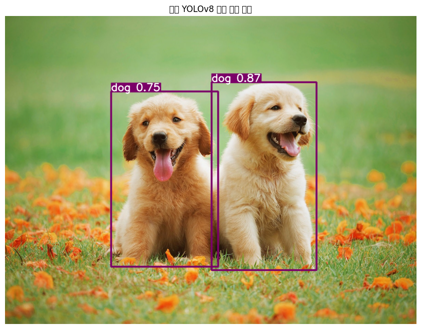

```
클래스: dog, 신뢰도: 0.87, 바운딩 박스: [602.20, 193.65, 908.10, 742.98]
클래스: dog, 신뢰도: 0.75, 바운딩 박스: [309.01, 220.69, 621.53, 732.43]
클래스 수: 80
클래스 목록:
0: person
1: bicycle
2: car
3: motorcycle
4: airplane
5: bus
6: train
7: truck
8: boat
9: traffic light
10: fire hydrant
```

[output cut: 69 more lines]

```python
from ultralytics import YOLO
import cv2
import matplotlib.pyplot as plt

# 원본 YOLOv8 모델 로드
model = YOLO('yolov8n.pt')

# 테스트 데이터셋 경로 (COCO 형식의 데이터셋 사용)
# test_data = 'coco128_custom.yaml'

# 모델 평가
results = model.val(data=test_data, conf=0.25, iou=0.5)

# 결과 출력
print("원본 YOLOv8 모델 성능:")
print(f"mAP50: {results.box.map50:.4f}")
print(f"mAP50-95: {results.box.map:.4f}")

# 샘플 이미지에 대한 예측
sample_image = cv2.imread('Dog_rawPixel01.jpg')
sample_results = model(sample_image)

# 결과 시각화
img_with_boxes = sample_results[0].plot()
plt.figure(figsize=(12, 8))
plt.imshow(cv2.cvtColor(img_with_boxes, cv2.COLOR_BGR2RGB))
plt.axis('off')
plt.title("원본 YOLOv8 모델 예측 결과")
plt.show()

# 예측 결과 분석
for r in sample_results:
    for box in r.boxes:
        class_id = int(box.cls[0])
        confidence = float(box.conf[0])
        x1, y1, x2, y2 = box.xyxy[0].tolist()
        print(f"클래스: {model.names[class_id]}, 신뢰도: {confidence:.2f}, 바운딩 박스: [{x1:.2f}, {y1:.2f}, {x2:.2f}, {y2:.2f}]")

# 클래스 수 출력
print(f"클래스 수: {len(model.names)}")
print("클래스 목록:")
for i, name in model.names.items():
    print(f"{i}: {name}")
```

### YOLOv8 모델 정보

- 버전: Ultralytics 8.3.16
- Python 버전: Python-3.10.12
- PyTorch 버전: torch-2.4.1+cu121
- CUDA: 사용되는 GPU (Tesla T4, 15102MiB)
- 모델 요약:
  - 총 168 layers
  - 3,151,904 개의 파라미터
  - 0 gradients
  - 8.7 GFLOPs (FLOPs는 부동소수점 연산 횟수를 나타냄)

```
val: Scanning /content/coco128/labels/train2017.cache... 126 images, 2 backgrounds, 0 corrupt: 100%|██████████| 128/128 [00:00<?, ?it/s]
```

### 검증 단계

```
Images  Instances      Box(P          R      mAP50  mAP50-95): 100%|██████████| 8/8 [00:03<00:00,  2.61it/s]
                   all        128        929      0.699      0.493      0.626      0.494
                person         61        254       0.84      0.661       0.78      0.609
               bicycle          3          6      0.667      0.333      0.499       0.43
                   car         12         46      0.909      0.217      0.571      0.406
            motorcycle          4          5      0.667        0.8      0.825      0.671
              airplane          5          6        0.8      0.667        0.8      0.612
                   bus          5          7      0.556      0.714      0.794      0.742
                 train          3          3          1      0.667      0.833      0.733
                 truck          5         12          1       0.25      0.625      0.444
                 ...
```

### 클래스별 성능

- "all" 클래스(모든 클래스 통합):
  - 이미지 수: 128
  - 인스턴스 수: 929
  - Box P: 0.699 (정확도)
  - R: 0.493 (재현율)
  - mAP50: 0.626 (평균 정밀도에 대한 값)
  - mAP50-95: 0.494
- 특정 클래스 예시:
  - 사람(person): P: 0.84, R: 0.661, mAP50: 0.78
  - 자동차(car): P: 0.909, R: 0.217, mAP50: 0.571
  - 개(dog): P: 0.615, R: 0.889, mAP50: 0.766
  - 과일(banana): P: 0.0, R: 0.0, mAP50: 0.0 (모델이 과일 인식에 실패)

```
Speed: 0.3ms preprocess, 5.2ms inference, 0.0ms loss, 4.8ms postprocess per image
Results saved to runs/detect/val2
원본 YOLOv8 모델 성능:
mAP50: 0.6260
mAP50-95: 0.4942
```

### 성능 데이터

- 속도:
  - 이미지 전처리: 0.3ms
  - 추론(inference): 5.2ms
  - 손실(loss): 0.0ms
  - 후처리(postprocess): 4.8ms
- 최종 성능 결과
  - YOLOv8 모델의 성능 지표:
  - mAP50: 0.6260 (0.626)
  - mAP50-95: 0.4942 (0.4942)

```
주요 지표인 mAP50과 mAP50-95를 분석

mAP50 (Mean Average Precision at IoU=0.50): 0.6260

이 값은 IoU(Intersection over Union) 임계값이 0.5일 때의 평균 정밀도를 나타냅니다.
0.6260은 62.60%의 정확도를 의미합니다.
이는 모델이 객체의 위치를 대략적으로 잘 찾아내고 있음을 나타냅니다.


mAP50-95 (Mean Average Precision at IoU=0.50:0.95): 0.4942
이 값은 IoU 임계값을 0.5에서 0.95까지 변화시키면서 계산한 평균 정밀도의 평균입니다.

0.4942는 49.42%의 정확도를 의미합니다.

이 값이 mAP50보다 낮은 것은 정상적이며, 더 엄격한 기준으로 평가했기 때문입니다.

성능 평가:
일반적인 기준:

mAP50이 0.6 이상이면 괜찮은 성능으로 간주됩니다.
mAP50-95가 0.4 이상이면 준수한 성능으로 볼 수 있습니다.

이 모델의 경우:
mAP50이 0.6260으로, 기본적인 객체 탐지 능력이 양호합니다.
mAP50-95가 0.4942로, 더 엄격한 기준에서도 준수한 성능을 보여줍니다.

해석:
이 모델은 객체의 대략적인 위치를 잘 찾아내며, 정확한 경계 상자 예측에서도 준수한 성능을 보입니다.
일반적인 객체 탐지 작업에 적합한 수준의 성능을 가지고 있습니다.
개선 가능성:

더 높은 성능이 필요하다면, 모델 아키텍처 개선, 데이터 증강, 더 긴 훈련 시간 등을 통해 성능을 향상시킬 수 있습니다.
용도에 따른 평가:

일반적인 객체 탐지 작업에는 충분한 성능입니다.
매우 정밀한 경계 상자가 필요한 특수한 응용 분야에서는 추가적인 개선이 필요할 수 있습니다.
결론적으로, 이 YOLOv8 모델은 전반적으로 양호한 성능을 보여주고 있으며, 대부분의 일반적인 객체 탐지 작업에 적합할 것으로 판단됩니다. 특정 응용 분야나 더 높은 정확도가 요구되는 경우에는 추가적인 최적화나 훈련이 필요할 수 있습니다.
```

```
Ultralytics 8.3.16 🚀 Python-3.10.12 torch-2.4.1+cu121 CUDA:0 (Tesla T4, 15102MiB)
YOLOv8n summary (fused): 168 layers, 3,151,904 parameters, 0 gradients, 8.7 GFLOPs
```

```
val: Scanning /content/coco128/labels/train2017.cache... 126 images, 2 backgrounds, 0 corrupt: 100%|██████████| 128/128 [00:00<?, ?it/s]
                 Class     Images  Instances      Box(P          R      mAP50  mAP50-95): 100%|██████████| 8/8 [00:04<00:00,  1.90it/s]
```

```
                   all        128        929      0.699      0.493      0.626      0.494
                person         61        254       0.84      0.661       0.78      0.609
               bicycle          3          6      0.667      0.333      0.499       0.43
                   car         12         46      0.909      0.217      0.571      0.406
            motorcycle          4          5      0.667        0.8      0.825      0.671
              airplane          5          6        0.8      0.667        0.8      0.612
                   bus          5          7      0.556      0.714      0.794      0.742
                 train          3          3          1      0.667      0.833      0.733
                 truck          5         12          1       0.25      0.625      0.444
                  boat          2          6        0.5      0.167      0.374     0.0748
         traffic light          4         14      0.667      0.143      0.429      0.386
             stop sign          2          2          1        0.5       0.75        0.6
                 bench          5          9          1      0.222      0.611      0.412
                  bird          2         16      0.917      0.688      0.825      0.493
                   cat          4          4          1          1      0.995      0.821
                   dog          9          9      0.615      0.889      0.766      0.627
                 horse          1          2      0.667          1      0.995      0.514
              elephant          4         17      0.929      0.765      0.874      0.706
                  bear          1          1          1          1      0.995      0.995
                 zebra          2          4          1          1      0.995      0.973
               giraffe          4          9      0.889      0.889      0.926      0.712
              backpack          4          6      0.667      0.333      0.556      0.364
              umbrella          4         18          1      0.444      0.722      0.527
               handbag          9         19          0          0          0          0
                   tie          6          7      0.833      0.714      0.785      0.583
              suitcase          2          4        0.5        0.5      0.539      0.479
               frisbee          5          5        0.8        0.8      0.839      0.775
                  skis          1          1          1          1      0.995      0.497
             snowboard          2          7        0.8      0.571      0.744      0.555
           sports ball          6          6      0.667      0.333      0.556      0.369
                  kite          2         10        0.8        0.4      0.619      0.271
          baseball bat          4          4          1       0.25      0.625      0.375
        baseball glove          4          7       0.75      0.429      0.642      0.465
            skateboard          3          5          1        0.6        0.8      0.563
         tennis racket          5          7      0.667      0.286      0.524      0.424
                bottle          6         18      0.545      0.333      0.382       0.27
            wine glass          5         16      0.714      0.312      0.559       0.45
                   cup         10         36      0.667      0.278      0.503      0.419
                  fork          6          6          1      0.167      0.583      0.525
                 knife          7         16      0.778      0.438      0.656      0.481
```

[output cut: 25 more lines]

```
          refrigerator          5          5      0.667        0.4      0.598      0.489
                  book          6         29       0.75      0.103      0.423      0.311
                 clock          8          9      0.778      0.778       0.85      0.743
                  vase          2          2        0.4          1      0.828        0.8
              scissors          1          1          0          0          0          0
            teddy bear          6         21          1      0.333      0.667      0.487
            toothbrush          2          5          1        0.4        0.7      0.469
Speed: 0.5ms preprocess, 5.1ms inference, 0.0ms loss, 9.1ms postprocess per image
Results saved to runs/detect/val3
원본 YOLOv8 모델 성능:
mAP50: 0.6260
mAP50-95: 0.4942

0: 640x448 1 umbrella, 2 chairs, 1 couch, 1 bed, 1 dining table, 1 book, 48.3ms
Speed: 2.3ms preprocess, 48.3ms inference, 1.7ms postprocess per image at shape (1, 3, 640, 448)
```

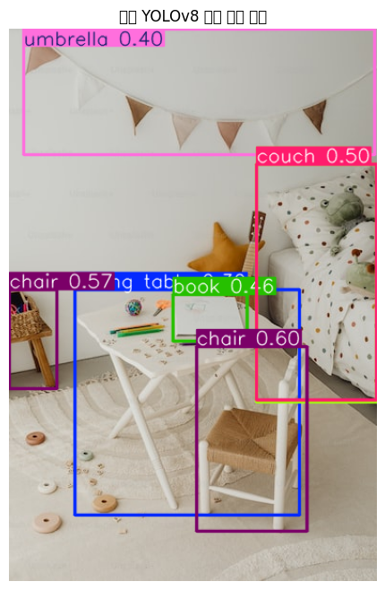

```
클래스: chair, 신뢰도: 0.60, 바운딩 박스: [197.60, 334.23, 313.21, 528.42]
클래스: chair, 신뢰도: 0.57, 바운딩 박스: [0.00, 274.12, 50.74, 378.62]
클래스: couch, 신뢰도: 0.50, 바운딩 박스: [260.07, 142.78, 386.80, 390.63]
클래스: book, 신뢰도: 0.46, 바운딩 박스: [172.28, 279.28, 250.58, 328.04]
클래스: bed, 신뢰도: 0.44, 바운딩 박스: [260.65, 142.66, 386.50, 392.55]
클래스: umbrella, 신뢰도: 0.40, 바운딩 박스: [15.75, 0.23, 384.39, 132.08]
클래스: dining table, 신뢰도: 0.30, 바운딩 박스: [69.72, 274.91, 305.50, 511.90]
클래스 수: 80
클래스 목록:
0: person
1: bicycle
2: car
3: motorcycle
4: airplane
5: bus
```

[output cut: 74 more lines]

```python
from ultralytics import YOLO
import cv2
import matplotlib.pyplot as plt

# 원본 YOLOv8 모델 로드
model = YOLO('yolov8n.pt')

# 테스트 데이터셋 경로 (COCO 형식의 데이터셋 사용)
test_data = 'coco128_custom.yaml'

# 모델 평가
results = model.val(data=test_data, conf=0.25, iou=0.5)

# 결과 출력
print("원본 YOLOv8 모델 성능:")
print(f"mAP50: {results.box.map50:.4f}")
print(f"mAP50-95: {results.box.map:.4f}")

# 샘플 이미지에 대한 예측
sample_image = cv2.imread('life_unsplash.jpeg')
sample_results = model(sample_image)

# 결과 시각화
img_with_boxes = sample_results[0].plot()
plt.figure(figsize=(12, 8))
plt.imshow(cv2.cvtColor(img_with_boxes, cv2.COLOR_BGR2RGB))
plt.axis('off')
plt.title("원본 YOLOv8 모델 예측 결과")
plt.show()

# 예측 결과 분석
for r in sample_results:
    for box in r.boxes:
        class_id = int(box.cls[0])
        confidence = float(box.conf[0])
        x1, y1, x2, y2 = box.xyxy[0].tolist()
        print(f"클래스: {model.names[class_id]}, 신뢰도: {confidence:.2f}, 바운딩 박스: [{x1:.2f}, {y1:.2f}, {x2:.2f}, {y2:.2f}]")

# 클래스 수 출력
print(f"클래스 수: {len(model.names)}")
print("클래스 목록:")
for i, name in model.names.items():
    print(f"{i}: {name}")
```

```
클래스: chair, 신뢰도: 0.60, 바운딩 박스: [197.60, 334.23, 313.21, 528.42]
클래스: chair, 신뢰도: 0.57, 바운딩 박스: [0.00, 274.12, 50.74, 378.62]
클래스: couch, 신뢰도: 0.50, 바운딩 박스: [260.07, 142.78, 386.80, 390.63]
클래스: book, 신뢰도: 0.46, 바운딩 박스: [172.28, 279.28, 250.58, 328.04]
클래스: bed, 신뢰도: 0.44, 바운딩 박스: [260.65, 142.66, 386.50, 392.55]
클래스: umbrella, 신뢰도: 0.40, 바운딩 박스: [15.75, 0.23, 384.39, 132.08]
클래스: dining table, 신뢰도: 0.30, 바운딩 박스: [69.72, 274.91, 305.50, 511.90]

이 결과에서 주목할 점:

신뢰도: 대부분의 탐지가 중간 정도의 신뢰도(0.4~0.6)를 가지고 있어, 모델이 완전히 확신하지는 않지만 어느 정도 신뢰할 만한 탐지를 했음을 나타냅니다.
중복 탐지: 의자가 두 번 탐지되었는데, 이는 실제로 두 개의 의자가 있거나 같은 의자를 다르게 인식했을 가능성이 있습니다.
혼동: 소파와 침대가 거의 같은 위치에 탐지되었는데, 이는 모델이 이 두 객체를 구분하는 데 어려움을 겪고 있음을 나타냅니다.
낮은 신뢰도 탐지: 식탁의 신뢰도가 30%로 가장 낮아, 이 탐지는 다소 불확실할 수 있습니다.
다양한 객체: 모델이 가구(의자, 소파, 침대, 식탁)부터 작은 물건(책)과 우산까지 다양한 종류의 객체를 탐지할 수 있음을 보여줍니다.
```

```
Ultralytics 8.3.16 🚀 Python-3.10.12 torch-2.4.1+cu121 CUDA:0 (Tesla T4, 15102MiB)
YOLOv8l summary (fused): 268 layers, 43,668,288 parameters, 0 gradients, 165.2 GFLOPs
```

```
val: Scanning /content/coco128/labels/train2017.cache... 126 images, 2 backgrounds, 0 corrupt: 100%|██████████| 128/128 [00:00<?, ?it/s]
                 Class     Images  Instances      Box(P          R      mAP50  mAP50-95): 100%|██████████| 8/8 [00:05<00:00,  1.34it/s]
```

```
                   all        128        929      0.788      0.723      0.793      0.667
                person         61        254       0.88      0.748      0.846      0.726
               bicycle          3          6          1      0.333      0.667       0.55
                   car         12         46      0.955      0.457      0.711      0.473
            motorcycle          4          5      0.833          1      0.962      0.853
              airplane          5          6          1          1      0.995      0.986
                   bus          5          7      0.833      0.714      0.833      0.762
                 train          3          3          1          1      0.995      0.973
                 truck          5         12        0.6        0.5      0.566      0.393
                  boat          2          6          1      0.667      0.833      0.595
         traffic light          4         14          1      0.214      0.607      0.423
             stop sign          2          2          1          1      0.995      0.895
                 bench          5          9      0.857      0.667      0.809      0.715
                  bird          2         16          1          1      0.995      0.734
                   cat          4          4          1          1      0.995      0.926
                   dog          9          9      0.818          1      0.995      0.901
                 horse          1          2          1          1      0.995      0.846
              elephant          4         17          1      0.941      0.971      0.887
                  bear          1          1          1          1      0.995      0.895
                 zebra          2          4          1          1      0.995       0.98
               giraffe          4          9      0.889      0.889      0.938      0.793
              backpack          4          6          1      0.667      0.833      0.627
              umbrella          4         18      0.889      0.889      0.928        0.7
               handbag          9         19      0.667      0.316      0.514      0.406
                   tie          6          7      0.833      0.714      0.833      0.705
              suitcase          2          4          1       0.75      0.875      0.732
               frisbee          5          5        0.8        0.8      0.879      0.793
                  skis          1          1          1          1      0.995      0.895
             snowboard          2          7          1      0.857      0.928      0.834
           sports ball          6          6        0.6        0.5      0.648      0.423
                  kite          2         10        0.6        0.3      0.508      0.146
          baseball bat          4          4        0.8          1      0.995      0.513
        baseball glove          4          7      0.667      0.571      0.685      0.465
            skateboard          3          5        0.6        0.6      0.668      0.513
         tennis racket          5          7      0.667      0.571      0.715      0.272
                bottle          6         18      0.733      0.611      0.643      0.521
            wine glass          5         16      0.917      0.688      0.815      0.602
                   cup         10         36      0.903      0.778      0.851      0.679
                  fork          6          6       0.75        0.5      0.604      0.457
                 knife          7         16        0.8       0.75      0.816      0.643
```

[output cut: 25 more lines]

```
          refrigerator          5          5        0.8        0.8      0.879      0.761
                  book          6         29      0.727      0.276      0.523      0.396
                 clock          8          9        0.8      0.889      0.911      0.772
                  vase          2          2      0.333          1      0.995      0.995
              scissors          1          1          0          0          0          0
            teddy bear          6         21      0.938      0.714      0.845      0.681
            toothbrush          2          5          1          1      0.995      0.844
Speed: 0.2ms preprocess, 30.2ms inference, 0.0ms loss, 1.5ms postprocess per image
Results saved to runs/detect/val4
원본 YOLOv8 모델 성능:
mAP50: 0.7933
mAP50-95: 0.6669

0: 640x448 1 chair, 1 bed, 1 dining table, 1 book, 1 scissors, 59.4ms
Speed: 3.0ms preprocess, 59.4ms inference, 2.1ms postprocess per image at shape (1, 3, 640, 448)
```

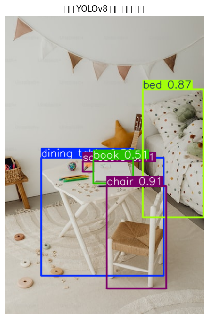

```
클래스: chair, 신뢰도: 0.91, 바운딩 박스: [198.58, 331.67, 314.12, 531.07]
클래스: bed, 신뢰도: 0.87, 바운딩 박스: [268.38, 143.27, 386.54, 392.72]
클래스: book, 신뢰도: 0.51, 바운딩 박스: [172.49, 279.84, 249.48, 326.53]
클래스: scissors, 신뢰도: 0.41, 바운딩 박스: [151.41, 284.57, 172.81, 303.06]
클래스: dining table, 신뢰도: 0.39, 바운딩 박스: [70.52, 276.22, 309.80, 506.33]
클래스 수: 80
클래스 목록:
0: person
1: bicycle
2: car
3: motorcycle
4: airplane
5: bus
6: train
7: truck
```

[output cut: 72 more lines]

```python
from ultralytics import YOLO
import cv2
import matplotlib.pyplot as plt

# 원본 YOLOv8 모델 로드
model = YOLO('yolov8l.pt')

# 테스트 데이터셋 경로 (COCO 형식의 데이터셋 사용)
test_data = 'coco128_custom.yaml'

# 모델 평가
results = model.val(data=test_data, conf=0.25, iou=0.5)

# 결과 출력
print("원본 YOLOv8 모델 성능:")
print(f"mAP50: {results.box.map50:.4f}")
print(f"mAP50-95: {results.box.map:.4f}")

# 샘플 이미지에 대한 예측
sample_image = cv2.imread('life_unsplash.jpeg')
sample_results = model(sample_image)

# 결과 시각화
img_with_boxes = sample_results[0].plot()
plt.figure(figsize=(12, 8))
plt.imshow(cv2.cvtColor(img_with_boxes, cv2.COLOR_BGR2RGB))
plt.axis('off')
plt.title("원본 YOLOv8 모델 예측 결과")
plt.show()

# 예측 결과 분석
for r in sample_results:
    for box in r.boxes:
        class_id = int(box.cls[0])
        confidence = float(box.conf[0])
        x1, y1, x2, y2 = box.xyxy[0].tolist()
        print(f"클래스: {model.names[class_id]}, 신뢰도: {confidence:.2f}, 바운딩 박스: [{x1:.2f}, {y1:.2f}, {x2:.2f}, {y2:.2f}]")

# 클래스 수 출력
print(f"클래스 수: {len(model.names)}")
print("클래스 목록:")
for i, name in model.names.items():
    print(f"{i}: {name}")
```

[output not shown]

### 모델 요약

```python
from ultralytics import YOLO
import os

# 모델 로드
all_model_list = ['yolov8n', 'yolov8s', 'yolov8m', 'yolov8l', 'yolov8x']

for one_model in all_model_list:
    model = YOLO(f"{one_model}.pt")

    # 모델 요약 정보 출력
    print(f"\n{one_model} 모델 정보:")
    # print(model)

    # 모델 레이어 수 확인
    num_layers = len(list(model.model.parameters()))
    print(f"총 레이어 수: {num_layers}")

    # 모델 파라미터 수 확인
    num_params = sum(p.numel() for p in model.model.parameters())
    print(f"총 파라미터 수: {num_params:,}")

    # 모델 파일 용량 확인
    model_path = f"{one_model}.pt"
    file_size = os.path.getsize(model_path) / (1024 ** 2)  # 파일 크기를 MB 단위로 변환
    print(f"모델 파일 크기: {file_size:.2f} MB")
```

```
yolov8n 모델 정보:
총 레이어 수: 184
총 파라미터 수: 3,157,200
모델 파일 크기: 6.25 MB

yolov8s 모델 정보:
총 레이어 수: 184
총 파라미터 수: 11,166,560
모델 파일 크기: 21.54 MB

yolov8m 모델 정보:
총 레이어 수: 244
총 파라미터 수: 25,902,640
모델 파일 크기: 49.72 MB

yolov8l 모델 정보:
총 레이어 수: 304
총 파라미터 수: 43,691,520
모델 파일 크기: 83.73 MB

yolov8x 모델 정보:
총 레이어 수: 304
총 파라미터 수: 68,229,648
모델 파일 크기: 130.55 MB
```

```python
from ultralytics import YOLO

# 모델 로드
model = YOLO("yolov8n.pt")  # 'yolov8n', 'yolov8s', 'yolov8m', 'yolov8l', 'yolov8x' 중 선택

# 모델 레이어 수 확인
num_layers = len(list(model.model.parameters()))
print(f"YOLOv8n 모델의 총 레이어 수: {num_layers}")

# 모델 요약
print(model.model)
```

[output not shown]

[output cut: 299 more lines]

[output not shown]